#### 01/2024

#### Máster de Ciencia de Datos de la UOC

# Estudio Modelos: Conjunto de datos refinado

## Índice

- Inicialización de librerías y definición función recurrente
- Estudio modelos
  - Random Forest
  - Regresión Logística
  - Máquinas de soporte vectorial
  - Clasificador bayesiano ingenuo
  - KNN - K vecinos más cercanos
  - Comparativa y predicción conjunto test
- Enfoques alternativos
  - Eliminación de una de las variables de día
  - Separación en dos datasets a partir de persona física o jurídica
  - Modelo caja negra vs caja blanca

En este notebook se aplican los mismos modelos presentados en el tercer notebook de modelos con el dataset del primer ciclo. En este caso todas las explicaciones de los modelos son obviadas para enfocar el notebook en los resultados.

Además, se hacen unos pequeños estudios extras al final para explorar el comportamiento de los datos al enfocarlos desde diferentes perspectivas.

## Inicialización de librerías y definición función recurrente

Como en el anterior notebook, se lee el dataset enriquecido, se inician las librerías y se define la función recurrente.

```python
from sklearn.linear_model import LogisticRegression
from sklearn.ensemble import RandomForestClassifier
from sklearn.svm import SVC
from sklearn.naive_bayes import GaussianNB
from sklearn.neighbors import KNeighborsClassifier
from sklearn.tree import DecisionTreeClassifier
from sklearn import tree
from sklearn.model_selection import GridSearchCV, RepeatedStratifiedKFold, RandomizedSearchCV
from sklearn.model_selection import train_test_split, cross_val_score
from sklearn.metrics import f1_score, recall_score, precision_score
from imblearn.pipeline import make_pipeline
from imblearn.over_sampling import SMOTE
from pyspark.sql import SparkSession
from matplotlib import pyplot as plt
import pandas as pd
import numpy as np

# se inicia sesion de spark
spark = SparkSession.builder.appName('Read Files').getOrCreate()
```

Lectura dataset enriquecido.

```python
consolidacion = spark.read.parquet("/Archivos/consolidacionSegundoCiclo.parquet").toPandas()
```

```python
X = consolidacion.drop(columns=['IND_CLIENTE'])
y = consolidacion['IND_CLIENTE'].astype('int')

X_train, X_test, y_train, y_test = train_test_split(X, y, test_size=0.2, random_state=10)
```

Definición función recurrente.

```python
def cross_validation_model(model, X_train, y_train, param_grid, typeSearch, n_iter=10):
    """Esta función aplica validación cruzada con 5 subgrupos estratificados para un tipo de modelo
       en particular, con una búsqueda del mejor conjunto de hiperparámetros evaluando el f1 score.
       La búsqueda puede ser aleatoria si el conjunto de hiperparámetros es amplio o completa si
       se quiere barrer todas las combinaciones de hiperparámetros.

       Los datos de las métricas f1 score, recall y precisión son almacenados junto con el resultado
       de la validación cruzada. El modelo forma parte dee una pipeline donde el primer paso es
       un oversampling de tipo SMOTE."""

    # se definen los subgrupos
    kf = RepeatedStratifiedKFold(n_splits=5, random_state=10)
    # se definen los pasos de la pipeline
    pipeline = make_pipeline(SMOTE(sampling_strategy=0.1,random_state=10),
                             model)
    scoring=['f1', 'recall', 'precision']

    if typeSearch == "random":
        grid_search = RandomizedSearchCV(pipeline, param_distributions=param_grid,
                                         scoring=scoring, refit="f1", cv=kf, n_iter=n_iter, n_jobs=-1)
    if typeSearch == "full":
        grid_search = GridSearchCV(pipeline, param_grid=param_grid, scoring=scoring, refit="f1", cv=kf, n_jobs=-1)

    results = grid_search.fit(X_train, y_train)
    return results
```

## Estudio modelos

### Random Forest

En este apartado se define un modelo random forest base como anteriormente y se explora el ranking de importancia con las nuevas variables. En este caso se ha hecho una búsqueda completa de hiperparámetros en vez de aleatoria para tener el mejor conjunto posible.

```python
model = RandomForestClassifier()

param_grid = {"randomforestclassifier__n_estimators": [50,100,150],
              "randomforestclassifier__max_depth": [8, 12],
              "randomforestclassifier__max_features": ["sqrt", "log2"],
              "randomforestclassifier__min_samples_split": [2, 3, 4]}

randomForestResults = cross_validation_model(model, X_train, y_train, param_grid, "full")
```

Mejores parámetros.

```python
randomForestResults.best_params_
```

```
{'randomforestclassifier__max_depth': 12,
 'randomforestclassifier__max_features': 'sqrt',
 'randomforestclassifier__min_samples_split': 4,
 'randomforestclassifier__n_estimators': 100}
```

Guardado de resultados.

```python
resultsList = []
results = []

results.extend(["Random Forest Base",
               randomForestResults.cv_results_["mean_test_f1"][randomForestResults.best_index_],
               randomForestResults.cv_results_["mean_test_recall"][randomForestResults.best_index_],
               randomForestResults.cv_results_["mean_test_precision"][randomForestResults.best_index_]])

resultsList.append(results)
pd.DataFrame(resultsList, columns=['Modelo','f1','recall','precision'])
```

|  | Modelo | f1 | recall | precision |
| --- | --- | --- | --- | --- |
| 0 | Random Forest Base | 0.854589 | 0.746937 | 0.998924 |

Se muestra el orden por importancia, en este caso como el último atributo tiene una relevancia con órdenes de magnitud muy pequeños, se ha mostrado en notación científica.

```python
# se muestra el ránking por importancia
pd.DataFrame(randomForestResults.best_estimator_.steps[1][1].feature_importances_,
             index=X_train.columns).sort_values(by=0, ascending=False).rename(columns = {0: "Importancia"})
```

|  | Importancia |
| --- | --- |
| diasParaUltimaSesion | 3.370796e-01 |
| numSesiones | 2.788232e-01 |
| diasParaUltimoConsumo | 2.054246e-01 |
| numConsumos | 8.453705e-02 |
| tipoProducto | 1.848441e-02 |
| BONDAD_EMAIL_SIMP | 1.671849e-02 |
| PIB | 1.272679e-02 |
| sectorId_J | 8.901260e-03 |
| TIPOUSUARIO_PF | 7.586775e-03 |
| TIPOUSUARIO_PJ | 7.317637e-03 |
| CANAL_REGISTRO_1 | 6.354762e-03 |
| CANAL_REGISTRO_7 | 4.571499e-03 |
| CANAL_REGISTRO_3 | 2.375374e-03 |
| CANAL_REGISTRO_8 | 1.478344e-03 |
| sectorId_N | 1.146422e-03 |
| sectorId_S | 9.987304e-04 |
| CANAL_REGISTRO_2 | 7.956984e-04 |
| sectorId_I | 7.368139e-04 |
| sectorId_Q | 6.595243e-04 |
| TIPOUSUARIO_PX | 6.113394e-04 |
| sectorId_C | 6.006165e-04 |
| CANAL_REGISTRO_6 | 5.408212e-04 |
| sectorId_K | 4.342144e-04 |
| sectorId_M | 3.899265e-04 |
| sectorId_B | 3.278461e-04 |
| sectorId_D | 2.108660e-04 |
| sectorId_P | 1.356188e-04 |
| sectorId_O | 3.125036e-05 |
| sectorId_Z | 5.283644e-07 |

Se comprueba que ha habido pequeños cambios en la importancia de los atributos que ya habían sido mostrados en el anterior estudio. En este caso, la distribución ha variado lo suficiente para adecuar dos nuevos atributos, el tipoProducto que recogía si la moda de un producto gratuito era promocional o ficha básica y el PIB para la moda de las empresas consultadas por usuario. Esta reordenación podría explicar que las dos nuevas variables explican mejor alguna parte de la información para clasificar correctamente si un usuario va a ser cliente o no. Como se vió en el análisis exploratorio, hay diferencias entre las dos poblaciones para las dos variables, por lo que tiene sentido este resultado. No se puede decir lo mismo del sector de la moda de la empresa consultada, únicamente el sector_J está cercano al 1% de importancia, que si se recuerda en el anterior notebook, tuvo un score mucho mayor que todos los demás sectores.

Para mantener un argumento común al anterior notebook, se incluirán en el dataset final únicamente aquellos atributos que tienen una importancia superior al 1%.

```python
X = consolidacion[["numSesiones","diasParaUltimaSesion","diasParaUltimoConsumo",
                   "numConsumos","PIB","tipoProducto","BONDAD_EMAIL_SIMP"]]
y = consolidacion['IND_CLIENTE'].astype('int')

X_train, X_test, y_train, y_test = train_test_split(X, y, test_size=0.2, random_state=10)
```

Se guarda el resultado del modelo con el nuevo dataset.

```python
kf = RepeatedStratifiedKFold(n_splits=5, random_state=10)
pipeline = make_pipeline(SMOTE(sampling_strategy=0.1,random_state=10),
        RandomForestClassifier(n_estimators=randomForestResults.best_params_.get('randomforestclassifier__n_estimators'),
                               min_samples_split=randomForestResults.best_params_.get('randomforestclassifier__min_samples_split'),
                               max_features=randomForestResults.best_params_.get('randomforestclassifier__max_features'),
                               max_depth=randomForestResults.best_params_.get('randomforestclassifier__max_depth')))
results = []

results.extend(["Random Forest",
               np.mean(cross_val_score(pipeline, X_train, y_train, scoring='f1', cv=kf)),
               np.mean(cross_val_score(pipeline, X_train, y_train, scoring='recall', cv=kf)),
               np.mean(cross_val_score(pipeline, X_train, y_train, scoring='precision', cv=kf))])

resultsList.append(results)
pd.DataFrame(resultsList, columns=['Modelo','f1','recall','precision'])
```

|  | Modelo | f1 | recall | precision |
| --- | --- | --- | --- | --- |
| 0 | Random Forest Base | 0.854589 | 0.746937 | 0.998924 |
| 1 | Random Forest | 0.853398 | 0.804176 | 0.910095 |

Como se puede comprobar, en este caso, aunque el F1 score se mantenga y la precisión baje, el recall aumenta hasta el 0.8. Este resultado podría estar explicando que no únicamente puede ser interesante hacer una selección de variables por el tiempo de computación, si no que se pueden obtener mejores resultados ya que el modelo no tiene que entrenarse con un número de variables tan amplio, de forma que pueda aprender mejor con únicamente las variables relevantes.

### Regresión Logística

Se aplica el mismo procedimiento para regresión logística.

```python
model = LogisticRegression(max_iter=500)

param_grid = {"logisticregression__solver": ["lbfgs","liblinear","newton-cg"],
              "logisticregression__C": [10, 100, 1000, 5000, 10000]}

logisticRegressionResults = cross_validation_model(model, X_train, y_train, param_grid, "full")
```

Se obtienen, como mejores hiperparámetros:

```python
logisticRegressionResults.best_params_
```

```
{'logisticregression__C': 10000, 'logisticregression__solver': 'newton-cg'}
```

Con el siguiente valor de F1, recall y precisión (se guarda el resultado):

```python
results = []

results.extend(["Regresión logística",
               logisticRegressionResults.cv_results_["mean_test_f1"][logisticRegressionResults.best_index_],
               logisticRegressionResults.cv_results_["mean_test_recall"][logisticRegressionResults.best_index_],
               logisticRegressionResults.cv_results_["mean_test_precision"][logisticRegressionResults.best_index_]])

resultsList.append(results)
pd.DataFrame([results], columns=['Modelo','f1','recall','precision'])
```

|  | Modelo | f1 | recall | precision |
| --- | --- | --- | --- | --- |
| 0 | Regresión logística | 0.73051 | 0.804083 | 0.669462 |

### Máquinas de soporte vectorial

Se aplica el mismo procedimiento para las máquinas de soporte vectorial.

```python
model = SVC(max_iter=10000)

param_grid = {"svc__C": [0.1, 1, 10, 100],
              "svc__gamma": ["scale"],
              "svc__kernel": ["rbf"]}

svcResults = cross_validation_model(model, X_train, y_train, param_grid, "full")
```

El mejor conjunto de hiperparámetros es:

```python
svcResults.best_params_
```

```
{'svc__C': 100, 'svc__gamma': 'scale', 'svc__kernel': 'rbf'}
```

Con el siguiente valor de F1, recall y precisión (se guarda el resultado):

```python
results = []

results.extend(["Máquinas de soporte vectorial",
               svcResults.cv_results_["mean_test_f1"][svcResults.best_index_],
               svcResults.cv_results_["mean_test_recall"][svcResults.best_index_],
               svcResults.cv_results_["mean_test_precision"][svcResults.best_index_]])

resultsList.append(results)
pd.DataFrame([results], columns=['Modelo','f1','recall','precision'])
```

|  | Modelo | f1 | recall | precision |
| --- | --- | --- | --- | --- |
| 0 | Máquinas de soporte vectorial | 0.795866 | 0.795206 | 0.797361 |

### Clasificador bayesiano ingenuo

Para el clasificador bayesiano ingenuo:

```python
model = GaussianNB()

param_grid = {"gaussiannb__var_smoothing": np.logspace(-2,-12, num=11)}

naiveBayesResults = cross_validation_model(model, X_train, y_train, param_grid, "full")
```

En este caso, el mejor conjunto de hiperparámetros es:

```python
naiveBayesResults.best_params_
```

```
{'gaussiannb__var_smoothing': 0.0001}
```

Con el siguiente valor de F1, recall y precisión:

```python
results = []

results.extend(["Clasificador bayesiano ingenuo",
               naiveBayesResults.cv_results_["mean_test_f1"][naiveBayesResults.best_index_],
               naiveBayesResults.cv_results_["mean_test_recall"][naiveBayesResults.best_index_],
               naiveBayesResults.cv_results_["mean_test_precision"][naiveBayesResults.best_index_]])

resultsList.append(results)
pd.DataFrame([results], columns=['Modelo','f1','recall','precision'])
```

|  | Modelo | f1 | recall | precision |
| --- | --- | --- | --- | --- |
| 0 | Clasificador bayesiano ingenuo | 0.717741 | 0.560134 | 1.0 |

### KNN - K vecinos más cercanos

Los K vecinos más cercanos:

```python
model = KNeighborsClassifier()

param_grid = {"kneighborsclassifier__n_neighbors": [2,3,4,5,6],
              "kneighborsclassifier__weights": ["uniform","distance"],
              "kneighborsclassifier__p": [1,2]} # 1 equivalente a manhattan, 2 a distancia euclidiana

KNeighborsResults = cross_validation_model(model, X_train, y_train, param_grid, "full")
```

El mejor conjunto de hiperparámetros de este modelo es:

```python
KNeighborsResults.best_params_
```

```
{'kneighborsclassifier__n_neighbors': 2,
 'kneighborsclassifier__p': 2,
 'kneighborsclassifier__weights': 'distance'}
```

Con el siguiente valor de F1, recall y precisión:

```python
results = []

results.extend(["K vecinos más cercanos",
               KNeighborsResults.cv_results_["mean_test_f1"][KNeighborsResults.best_index_],
               KNeighborsResults.cv_results_["mean_test_recall"][KNeighborsResults.best_index_],
               KNeighborsResults.cv_results_["mean_test_precision"][KNeighborsResults.best_index_]])

resultsList.append(results)
pd.DataFrame([results], columns=['Modelo','f1','recall','precision'])
```

|  | Modelo | f1 | recall | precision |
| --- | --- | --- | --- | --- |
| 0 | K vecinos más cercanos | 0.830388 | 0.746036 | 0.936807 |

### Comparativa y predicción conjunto test

En la siguiente tabla se pueden observar los resultados obtenidos:

```python
pd.DataFrame(resultsList, columns=['Modelo','f1','recall','precision'])
```

|  | Modelo | f1 | recall | precision |
| --- | --- | --- | --- | --- |
| 0 | Random Forest Base | 0.854589 | 0.746937 | 0.998924 |
| 1 | Random Forest | 0.853398 | 0.804176 | 0.910095 |
| 2 | Regresión logística | 0.730510 | 0.804083 | 0.669462 |
| 3 | Máquinas de soporte vectorial | 0.795866 | 0.795206 | 0.797361 |
| 4 | Clasificador bayesiano ingenuo | 0.717741 | 0.560134 | 1.000000 |
| 5 | K vecinos más cercanos | 0.830388 | 0.746036 | 0.936807 |

Como se puede comprobar, el mejor modelo vuelve a ser nuevamente el random forest, aunque los resultados en comparación al primer conjunto de modelos con el dataset del primer ciclo, son bastante mejores sobretodo en el recall para todos los modelos, por lo que añadir las dos nuevas variables ha sido completamente satisfactorio. Sí que es cierto que la precisión ha bajado en comparación, pero al aumentar el recall se están identificando un mayor número de clientes. Como se dijo en la definición de las métricas, para el equipo de márketing puede ser más interesante aumentar la identificación de clientes aunque se hagan campañas de captación a algunos usuarios que nunca comprarán.

Como segunda opción se podría hablar de las máquinas de soporte vectorial, pero suponen un problema, ya que se ha tenido que fijar un máximo de iteraciones para obtener el hiperplano por tiempo de computación, así que no ha llegado a converger por si solo y pueden haber dudas sobre si el resultado de las métricas son realmente las mostradas.

Seguidamente, la regresión logística obtiene buenos resultados en el recall, pero la precisión es muy baja, mientras que el clasificador bayesiano ingenuo tiene la problemática contraria con un recall muy deficiente. El único modelo que también podría dar buenos resultados es el de K vecinos más cercanos, ya que tiene un recall cercano al 0.75 con una precisión alta.

```python
kf = RepeatedStratifiedKFold(n_splits=5, random_state=10)
pipeline = make_pipeline(SMOTE(sampling_strategy=0.1,random_state=10),
        RandomForestClassifier(n_estimators=randomForestResults.best_params_.get('randomforestclassifier__n_estimators'),
                               min_samples_split=randomForestResults.best_params_.get('randomforestclassifier__min_samples_split'),
                               max_features=randomForestResults.best_params_.get('randomforestclassifier__max_features'),
                               max_depth=randomForestResults.best_params_.get('randomforestclassifier__max_depth')))

Finalresults = [np.mean(cross_val_score(pipeline, X_train, y_train, scoring='f1', cv=kf)),
                np.mean(cross_val_score(pipeline, X_train, y_train, scoring='recall', cv=kf)),
                np.mean(cross_val_score(pipeline, X_train, y_train, scoring='precision', cv=kf))]

pipeline.fit(X_train, y_train)

Finalresults.extend([f1_score(y_test, pipeline.predict(X_test)),
                     recall_score(y_test, pipeline.predict(X_test)),
                     precision_score(y_test, pipeline.predict(X_test))])

pd.DataFrame([Finalresults], columns=['F1 val.','Recall val.','Precision val.','F1 test','Recall test','Precision test'])
```

|  | F1 val. | Recall val. | Precision val. | F1 test | Recall test | Precision test |
| --- | --- | --- | --- | --- | --- | --- |
| 0 | 0.852301 | 0.804558 | 0.909367 | 0.829876 | 0.796813 | 0.865801 |

Como se observa, en este caso el resultado en el conjunto de test es similar al de validación, por lo que se comprueba que no ha habido resultados inesperados. Únicamente ha bajado la precisión en 4 puntos, algo que es completamente normal. Sí que es cierto que con las dos nuevas variables el modelo no mejora la generalización como en el tercer notebook, pero puede ser normal al tener que aprender nueva información, además en este caso el recall es de 0.8 y anteriormente era de 0.7.

Como se dijo cuando se buscó la mejor estrategia, se hace un barrido de todos los ratios posibles con el mejor modelo para tratarlo como hiperparámetro a ajustar:

```python
def searchBestSamplingStrategy(X_train, y_train, percentageList, KFoldType, random_state, modelResults):
    """Esta función recibe un conjunto de entrenamiento y aplica validación cruzada para
       cada porcentaje de oversampling y devuelve un dataframe con los resultados de las métricas"""

    results = []
    for percentage in percentageList:

        if percentage == 0:
            pipeline = RandomForestClassifier(n_estimators=modelResults.best_params_.get('randomforestclassifier__n_estimators'),\
                                  min_samples_split=modelResults.best_params_.get('randomforestclassifier__min_samples_split'),\
                                  max_features=modelResults.best_params_.get('randomforestclassifier__max_features'),\
                                  max_depth=modelResults.best_params_.get('randomforestclassifier__max_depth'),
                                  random_state=random_state)
        if percentage != 0:
            pipeline = make_pipeline(SMOTE(sampling_strategy=percentage,random_state=random_state),
                         RandomForestClassifier(n_estimators=modelResults.best_params_.get('randomforestclassifier__n_estimators'),
                                  min_samples_split=modelResults.best_params_.get('randomforestclassifier__min_samples_split'),
                                  max_features=modelResults.best_params_.get('randomforestclassifier__max_features'),
                                  max_depth=modelResults.best_params_.get('randomforestclassifier__max_depth'),
                                  random_state=10))

        results.append([percentage,
                        np.mean(cross_val_score(pipeline, X_train, y_train, scoring='f1', cv=KFoldType)),
                        np.mean(cross_val_score(pipeline, X_train, y_train, scoring='recall', cv=KFoldType)),
                        np.mean(cross_val_score(pipeline, X_train, y_train, scoring='precision', cv=KFoldType))])

    return pd.DataFrame(results, columns=['percentage','mean_f1','mean_recall','mean_precision'])
```

```python
percentageList = [0,0.1,0.2,0.3,0.4,0.5,0.6,0.7,0.8,0.9,1]
resultsSamplingStrategy = searchBestSamplingStrategy(X_train, y_train, percentageList, kf, 10, randomForestResults)
resultsSamplingStrategy
```

|  | percentage | mean_f1 | mean_recall | mean_precision |
| --- | --- | --- | --- | --- |
| 0 | 0.0 | 0.870951 | 0.778881 | 0.988100 |
| 1 | 0.1 | 0.853398 | 0.804176 | 0.910095 |
| 2 | 0.2 | 0.752358 | 0.860467 | 0.669297 |
| 3 | 0.3 | 0.720148 | 0.879401 | 0.610053 |
| 4 | 0.4 | 0.696322 | 0.888133 | 0.573139 |
| 5 | 0.5 | 0.664280 | 0.893211 | 0.529697 |
| 6 | 0.6 | 0.625135 | 0.900616 | 0.479378 |
| 7 | 0.7 | 0.600228 | 0.904935 | 0.449587 |
| 8 | 0.8 | 0.567410 | 0.909586 | 0.412880 |
| 9 | 0.9 | 0.539173 | 0.913952 | 0.382878 |
| 10 | 1.0 | 0.513051 | 0.918840 | 0.356271 |

Se sigue encontrando que un ratio 1/10 de las poblaciones es el mejor para este estudio. Se comprueba que la mejora en el recall sin disminuir enormemente la precisión es la utilizada. Estos resultados podrían enseñarse al departamento pertinente del ecommerce para tratar esta información, ya que dependiendo de la estrategia que quiera seguir el equipo del gobierno del dato, de ventas, márketing o dirección, podría importarles en mayor medida maximizar aún más el recall aunque la precisión baje. Es decir, si se decidiera una estrategia de enviar campañas de captación al máximo posible de clientes potenciales sin importar tanto el número de envíos de correos o llamadas a usuarios que nunca comprarán, entonces puede que fuera más interesante los modelos con los ratios 2/10 hasta el 6/10, ya que aumenta el recall y la precisión no sería tan importante.

## Enfoques alternativos

Una vez se tiene un modelo con un dataset final, se exploran otros enfoques extras para comprender la diferencia de comportamiento si se hubiera seguido un camino diferente.

### Eliminación de una de las variables de día

Como se vió en el estudio de la correlación de Pearson entre las nuevas variables creadas aplicando feature engineering entre los atributos de número de días entre la fecha de registro y la fecha de última sesión o último consumo. Se encontró que la correlación entre estas dos variables era de 0.79, algo que es completamente normal, ya que si hay consumos a lo largo de días, también habrá que haber más número de sesiones para explorar los datos. Se acabaron dejando las dos variables en el primer ciclo para comprobar la importancia de cada una en el modelo, encontrando que cada una aportaba información para el entrenamiento, por lo que se acabaron dejando ambas en todo el estudio.

En este apartado se va a eliminar diasParaUltimoConsumo, ya que tiene menos peso en la importancia en comparación a diasParaUltimaSesion, de esta forma únicamente se mantendrá un atributo relacionado con las fechas, para comprobar si hay una redistribución de los pesos de cada atributo en el entrenamiento del modelo random forest con los mejores hiperparámetros que se calcularon anteriormente y si era necesario mantener las dos variables.

Por ello, se hace nuevamente la lectura eliminando la variable, se hace el entrenamiento con todo el conjunto de entrenamiento y se muestran las 10 variables más importantes.

```python
consolidacion = spark.read.parquet("/Archivos/consolidacionSegundoCiclo.parquet").toPandas()

# eliminación de la variable más correlacionada
X = consolidacion.drop(columns=['IND_CLIENTE','diasParaUltimoConsumo'])
y = consolidacion['IND_CLIENTE'].astype('int')

X_train, X_test, y_train, y_test = train_test_split(X, y, test_size=0.2, random_state=10)
```

```python
pipeline = make_pipeline(SMOTE(sampling_strategy=0.1,random_state=10),
        RandomForestClassifier(n_estimators=100, min_samples_split=4, max_features='sqrt', max_depth=12))
model = pipeline.fit(X_train, y_train)
```

```python
pd.DataFrame(model[1].feature_importances_,
             index=X_train.columns).sort_values(by=0, ascending=False).rename(columns = {0: "Importancia"}).head(10)
```

|  | Importancia |
| --- | --- |
| diasParaUltimaSesion | 0.477382 |
| numSesiones | 0.299616 |
| numConsumos | 0.113682 |
| BONDAD_EMAIL_SIMP | 0.023216 |
| tipoProducto | 0.017880 |
| PIB | 0.016885 |
| TIPOUSUARIO_PF | 0.009211 |
| sectorId_J | 0.008309 |
| TIPOUSUARIO_PJ | 0.008196 |
| CANAL_REGISTRO_1 | 0.006808 |

Se puede observar que diasParaUltimaSesion ahora adquiere aproximadamente el 50% del peso del total, redistribuyéndose el 20% del peso de diasParaUltimoConsumo entre la primera variable y en menor medida entre otras. Este comportamiento puede tener sentido ya que al estar tan correlacionadas, una gran parte de la información de diasParaUltimoConsumo ha ido a parar a la primera. Cuando estaban las dos, parte de la información que no explicaba la de sesión, entonces sí que dependía de la de consumos.

En este caso, se seleccionan las mismas variables junto con TIPOUSUARIO_PF, ya que en algunas ejecuciones del notebook está por encima del 1%.

```python
X = consolidacion[["numSesiones","diasParaUltimaSesion",
                   "numConsumos","PIB","tipoProducto","BONDAD_EMAIL_SIMP","TIPOUSUARIO_PF"]]
y = consolidacion['IND_CLIENTE'].astype('int')

X_train, X_test, y_train, y_test = train_test_split(X, y, test_size=0.2, random_state=10)
```

Se reentrena el modelo con las variables seleccionadas.

```python
kf = RepeatedStratifiedKFold(n_splits=5, random_state=10)
pipeline = make_pipeline(SMOTE(sampling_strategy=0.1,random_state=10),
        RandomForestClassifier(n_estimators=100, min_samples_split=4, max_features='sqrt', max_depth=12))

newResults = [np.mean(cross_val_score(pipeline, X_train, y_train, scoring='f1', cv=kf)),
                np.mean(cross_val_score(pipeline, X_train, y_train, scoring='recall', cv=kf)),
                np.mean(cross_val_score(pipeline, X_train, y_train, scoring='precision', cv=kf))]

pipeline.fit(X_train, y_train)

newResults.extend([f1_score(y_test, pipeline.predict(X_test)),
                     recall_score(y_test, pipeline.predict(X_test)),
                     precision_score(y_test, pipeline.predict(X_test))])

pd.DataFrame([newResults], columns=['F1 val.','Recall val.','Precision val.','F1 test','Recall test','Precision test'])
```

|  | F1 val. | Recall val. | Precision val. | F1 test | Recall test | Precision test |
| --- | --- | --- | --- | --- | --- | --- |
| 0 | 0.852353 | 0.79369 | 0.921682 | 0.844253 | 0.782869 | 0.916084 |

### Separación en dos datasets a partir de persona física o jurídica

Otro concepto que se podría tener es sobre en qué poblaciones habría que centrarse en cada momento, ya que cada población no tiene que ser tratada por el mismo departamento. Los usuarios identificados como personas jurídicas probablemente serán tratados por el departamento que esté especializado en empresas, mientras que otro departamento o equipo podría tratar con las personas físicas, por lo que se podría separar el dataset en dos subconjuntos de datasets, para obtener dos modelos que se enviarían separadamente al departamento pertinente.

Como se vió, las variables de TIPOUSUARIO no tienen una importancia global tan importante en el entrenamiento del modelo, pero cuando se hizo el análisis exploratorio de esa variable antes de utilizar one-hot-encoding, se encontró que había diferencias visibles entre las dos poblaciones. Si se recuerda, las personas jurídicas tenían más proporción de clientes y las físicas de no clientes, por lo que será interesante comprobar si hay diferencias visibles en el ránking de los dos datasets.

Para hacer la separación, se considera los usuarios PX que son indeterminados o no es seguro que sean personas jurídicas, como PJ. Además, no se incluye en este caso la variable diasParaUltimoConsumo, ya que este apartado se puede considerar un añadido al anterior.

```python
X_PF = consolidacion.drop(columns=['IND_CLIENTE','diasParaUltimoConsumo']).loc[consolidacion['TIPOUSUARIO_PF'] == 1]
y_PF = consolidacion.loc[consolidacion['TIPOUSUARIO_PF'] == 1]['IND_CLIENTE'].astype('int')

X_PJ = consolidacion.drop(columns=['IND_CLIENTE','diasParaUltimoConsumo']).loc[consolidacion['TIPOUSUARIO_PF'] == 0]
y_PJ = consolidacion.loc[consolidacion['TIPOUSUARIO_PF'] == 0]['IND_CLIENTE'].astype('int')

X_train_PF, X_test_PF, y_train_PF, y_test_PF = train_test_split(X_PF, y_PF, test_size=0.2, random_state=10)
X_train_PJ, X_test_PJ, y_train_PJ, y_test_PJ = train_test_split(X_PJ, y_PJ, test_size=0.2, random_state=10)
```

Se obtiene la importancia para las personas físicas:

```python
pipeline = make_pipeline(SMOTE(sampling_strategy=0.1,random_state=10),
        RandomForestClassifier(n_estimators=100, min_samples_split=4, max_features='sqrt', max_depth=12))
model = pipeline.fit(X_train_PF, y_train_PF)

pd.DataFrame(model[1].feature_importances_,
             index=X_train_PF.columns).sort_values(by=0, ascending=False).rename(columns = {0: "Importancia"}).head(10)
```

|  | Importancia |
| --- | --- |
| diasParaUltimaSesion | 0.507912 |
| numSesiones | 0.287542 |
| numConsumos | 0.108887 |
| BONDAD_EMAIL_SIMP | 0.031662 |
| PIB | 0.018124 |
| tipoProducto | 0.017480 |
| CANAL_REGISTRO_7 | 0.009404 |
| sectorId_N | 0.003085 |
| sectorId_S | 0.002118 |
| sectorId_J | 0.002111 |

Se obtiene la importancia para personas jurídicas:

```python
pipeline = make_pipeline(SMOTE(sampling_strategy=0.1,random_state=10),
        RandomForestClassifier(n_estimators=100, min_samples_split=4, max_features='sqrt', max_depth=12))
model = pipeline.fit(X_train_PJ, y_train_PJ)

pd.DataFrame(model[1].feature_importances_,
             index=X_train_PJ.columns).sort_values(by=0, ascending=False).rename(columns = {0: "Importancia"}).head(10)
```

|  | Importancia |
| --- | --- |
| diasParaUltimaSesion | 0.465956 |
| numSesiones | 0.316725 |
| numConsumos | 0.120049 |
| tipoProducto | 0.025820 |
| PIB | 0.017591 |
| CANAL_REGISTRO_1 | 0.012815 |
| sectorId_J | 0.011257 |
| BONDAD_EMAIL_SIMP | 0.009996 |
| CANAL_REGISTRO_3 | 0.003613 |
| CANAL_REGISTRO_7 | 0.001802 |

Se pueden encontrar diferencias destacables en los ránkings entre una población y otra. Las variables más importantes se mantienen en los mismos porcentajes, pero en personas físicas hay cambios en BONDAD_EMAIL_SIMP que aumenta la importancia y CANAL_REGISTRO_7 que roza el 1%.

En personas jurídicas los cambios se centran en CANAL_REGISTRO_1 y sectorId_J, con una disminución de BONDAD_EMAIL_SIMP.

Si se analiza por partes, la variable de la bondad del correo es más importante para clasificar a las personas físicas que las jurídicas, esto se puede deber a que las personas jurídicas, al representar a una empresa suelen rellenar correctamente ese campo, mientras que para personas físicas, al no tener esa representación, pueden rellenar ese campo de forma no correcta por no querer compartir el dato, entonces como los clientes potenciales se suelen fiar más de la plataforma, podría tener valor añadido para la clasificación.

Una explicación parecida se puede tener con CANAL_REGISTRO_7 y CANAL_REGISTRO_1. Estas dos variables binarias se han obtenido del mismo atributo inicial, por lo que son excluyentes. Para las personas físicas puede ser un valor añadido el saber si han llegado al ecommerce por el directorio popular número 7 y para las personas jurídicas que hayan navegado hasta el site por SEM (que es el campo representado en el 1 del canal).

Finalmente, para las personas jurídicas el sector de la información y comunicaciones (sectorId_J) puede ser importante para la clasificación. Por todo ello, diferentes poblaciones podrían tener diferentes lecturas.

Se va a obtener el resultado de cada modelo con todas las variables:

```python
resultsComparison = []
kf = RepeatedStratifiedKFold(n_splits=5, random_state=10)
pipeline = make_pipeline(SMOTE(sampling_strategy=0.1,random_state=10),
        RandomForestClassifier(n_estimators=100, min_samples_split=4, max_features='sqrt', max_depth=12))

newModel = ["PF",np.mean(cross_val_score(pipeline, X_train_PF, y_train_PF, scoring='f1', cv=kf)),
                np.mean(cross_val_score(pipeline, X_train_PF, y_train_PF, scoring='recall', cv=kf)),
                np.mean(cross_val_score(pipeline, X_train_PF, y_train_PF, scoring='precision', cv=kf))]

pipeline.fit(X_train_PF, y_train_PF)

newModel.extend([f1_score(y_test_PF, pipeline.predict(X_test_PF)),
                     recall_score(y_test_PF, pipeline.predict(X_test_PF)),
                     precision_score(y_test_PF, pipeline.predict(X_test_PF))])

resultsComparison.append(newModel)

pipeline = make_pipeline(SMOTE(sampling_strategy=0.1,random_state=10),
        RandomForestClassifier(n_estimators=100, min_samples_split=4, max_features='sqrt', max_depth=12))

newModel = ["PJ",np.mean(cross_val_score(pipeline, X_train_PJ, y_train_PJ, scoring='f1', cv=kf)),
                np.mean(cross_val_score(pipeline, X_train_PJ, y_train_PJ, scoring='recall', cv=kf)),
                np.mean(cross_val_score(pipeline, X_train_PJ, y_train_PJ, scoring='precision', cv=kf))]

pipeline.fit(X_train_PJ, y_train_PJ)

newModel.extend([f1_score(y_test_PJ, pipeline.predict(X_test_PJ)),
                     recall_score(y_test_PJ, pipeline.predict(X_test_PJ)),
                     precision_score(y_test_PJ, pipeline.predict(X_test_PJ))])

resultsComparison.append(newModel)

pd.DataFrame(resultsComparison, columns=['Type','F1 val.','Recall val.','Precision val.','F1 test','Recall test','Precision test'])
```

|  | Type | F1 val. | Recall val. | Precision val. | F1 test | Recall test | Precision test |
| --- | --- | --- | --- | --- | --- | --- | --- |
| 0 | PF | 0.817239 | 0.696867 | 0.988369 | 0.826291 | 0.709677 | 0.988764 |
| 1 | PJ | 0.872174 | 0.773831 | 0.998143 | 0.883817 | 0.791822 | 1.000000 |

Estos resultados ponen de manifiesto que, para diferentes enfoques, se pueden conseguir resultados un tanto dispares, por lo que es de especial interés el tener un equipo de expertos que vayan justificando qué se quiere conseguir y en qué camino dirigirse.

### Modelo caja negra vs caja blanca

En anteriores apartados se ha obtenido el mejor modelo final y se han explorado otros enfoques que se podían haber tratado a lo largo del proyecto. Además, a partir del análisis exploratorio junto con el ránking de variables más importantes, se pudo argumentar el por qué cada variable tenía un peso destacable en la correcta clasificación de los clientes potenciales. Se encontró que el modelo random forest es el mejor modelo disponible, pero por la naturaleza del mismo se plantea la dificultad de entender el por qué un usuario en específico se ha clasificado como cliente potencial. Esta problemática es importante, ya que aunque el estudio haya llegado a un modelo que pueda clasificar correctamente un gran porcentaje de los datos, si el cliente en un proyecto de ciencia de datos o el departamento de dirección de este ecommerce en específico pregunta cómo se ha llegado a tal conclusión cuando observa los datos unitariamente, se encuentra que es muy difícil el dar la respuesta de que una variable en concreto ha sido la determinante en un usuario en particular. Esto se debe a que el modelo que ha obtenido las mejores prestaciones es el random forest, un modelo de caja negra ya que la clasificación es una votación de un número determinado de predictores, así que tiene la problemática típica de aquellos modelos más complejos que suelen dar mejores resultados pero son menos interpretables que otros tipos.

Relacionado con esta casuística, se puede identificar la dicotomia entre la ODS número 9 que representa la industria y la innovación y la ODS de la dimensión de la diversidad y los derechos humanos, que trata de reducir la desigualdad en y entre los países. Con la primera se intenta innovar y obtener en cada nueva iteración mejores modelos para mejorar el rendimiento y obtener nuevas aplicaciones (y por ello actualmente se considera que el mundo está en una nueva revolución industrial), mientras que la ODS de la desigualdad intenta que no se utilicen y se creen cajas negras que sean tan difíciles de interpretar que acaben sesgando los tejidos productivos o lleguen a afectar a los usuarios. Como se dijo en la introducción, los datos del presente estudio estan anonimizados y no tienen sesgos de este tipo, pero sí que se ha llegado a un modelo de caja negra con el mismo tipo de dificultad que se tendría que tratar.

Un modelo más simple en comparación al random forest es el de un único árbol de decisión clasificador. Al tener un único árbol, se puede interpretar todo el camino que ha recorrido un registro hasta que se ha clasificado como una población u otra, por lo que se puede considerar de caja blanca. Este modelo no ha sido explorado anteriormente ya que el objetivo principal era de obtener el mejor resultado y el random forest era el más complejo, así que en este apartado se va a buscar los mejores hiperparámetros de un árbol de decisión para comparar sus resultados con el random forest.

Los hiperparámetros a explorar son los mismos del random forest sin añadir el número de predictores ya que en este caso es sólo uno.

```python
model = DecisionTreeClassifier()

param_grid = {"decisiontreeclassifier__max_depth": [8, 12, 16, 20],
             "decisiontreeclassifier__max_features": ["sqrt", "log2"],
             "decisiontreeclassifier__min_samples_split": [2, 3, 4, 5]}

decisiontreeResults = cross_validation_model(model, X_train, y_train, param_grid, "full")
```

El mejor conjunto de hiperparámetros es:

```python
decisiontreeResults.best_params_
```

```
{'decisiontreeclassifier__max_depth': 8,
 'decisiontreeclassifier__max_features': 'sqrt',
 'decisiontreeclassifier__min_samples_split': 2}
```

Con el siguiente valor de F1, recall y precisión:

```python
results = []

results.extend(["Árbol decisión",
               decisiontreeResults.cv_results_["mean_test_f1"][decisiontreeResults.best_index_],
               decisiontreeResults.cv_results_["mean_test_recall"][decisiontreeResults.best_index_],
               decisiontreeResults.cv_results_["mean_test_precision"][decisiontreeResults.best_index_]])

pd.DataFrame([results], columns=['Modelo','f1','recall','precision'])
```

|  | Modelo | f1 | recall | precision |
| --- | --- | --- | --- | --- |
| 0 | Árbol decisión | 0.825584 | 0.74337 | 0.940308 |

Estos resultados se podrían mostrar a dirección para determinar qué es lo que se quiere finalmente, como anteriomente se razonó con el porcentaje de ratio entre la clase mayoritaria y minoritaria. Es decir, si el objetivo final es que exista un modelo que clasifique automáticamente e identifique los clientes potenciales maximizando identificar al máximo número posible de usuarios, se podría utilizar el modelo de random forest. Si en cambio, se quiere obtener un modelo que sea completamente transparente y pueda justificar y mostrar cada variable utilizada, para, mejorar la estrategia de márketing, mover o potenciar recursos para maximizar las conversiones, entonces podría ser mejor utilizar un modelo de árbol de decisión aunque tenga peores prestaciones.

Se muestra visualmente el árbol de decisión hasta una profundidad de 3 sobre 8 para que se pueda comprender los caminos de decisión:

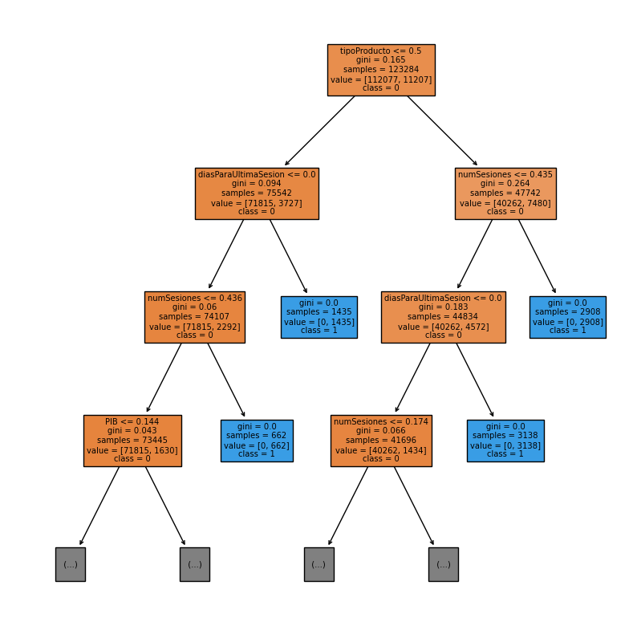

```python
fig, ax = plt.subplots(figsize=(10, 10))
tree.plot_tree(decisiontreeResults.best_estimator_[1],
                   feature_names=X_train.columns,
                   class_names=['0','1'],
                   filled=True, max_depth=3)
plt.show()
```

Por todo lo que se ha visto en este notebook final, los enfoques que se podían utilizar con este juego de datos eran muy variados, por lo que seguramente se han dejado temas sin tratar y podrían ser objetivos de futuros proyectos.